# Power Plants of Your State

*Feb. 4<sup>th</sup>, 2019*

**Overview**  
- You can learn the basic information of power plants in the U.S. from the "Power Plants of Your State" app.  
- The app is created based on EIA power plants [dataset](https://www.eia.gov/electricity/data/eia860M/).  
- The app is running on [yiapplege.shinyapps.io](https://yiapplege.shinyapps.io/PowerPlants/).  
- Codes can be found in [yiapplege's github](https://yiapplege.github.io/Data_JHU_Cousera/9-Data%20Product/A3/Pitch.html#1).  
- This pitch takes MA and all energy sources as an example.

**How to use:**  
1. Choose your state.  
2. Check all the energy sources that you are interested in.  
3. Enter the number of plant example you want to see.  
4. Click the "Let's go!" button.  
5. View the results in 3 tabs: Data, Plot and Map.  
6. Click the "Download the Data" button if you want to save the dataset.

## Results - Data

```
  Plant Name           Latitude       Longitude       Capacity (MW)
 Length:386         Min.   :41.26   Min.   :-73.405   Min.   :   1.00
 Class :character   1st Qu.:42.06   1st Qu.:-72.322   1st Qu.:   1.90
 Mode  :character   Median :42.22   Median :-71.674   Median :   2.65
                    Mean   :42.22   Mean   :-71.517   Mean   :  36.99
                    3rd Qu.:42.45   3rd Qu.:-71.049   3rd Qu.:   4.80
                    Max.   :42.85   Max.   : -3.228   Max.   :2375.60
```

This tab shows the summary of chosen plants as above. It also shows the information of your chosen plants. You can enter the number of plants you want to see from sidebar.

```
# A tibble: 2 x 8
# Groups:   Plant Name [2]
  `Plant Name` `Plant State` `Operating Year` County Latitude Longitude
  <chr>        <chr>         <chr>            <chr>     <dbl>     <dbl>
1 Northfield … MA            1973             Frank…     42.6     -72.5
2 Exelon Fram… MA            1970             Norfo…     42.3     -71.4
# ... with 2 more variables: `Capacity (MW)` <dbl>, Label <chr>
```

## Results - Plot

This tab shows the total power capacity over years grouped by energy source.

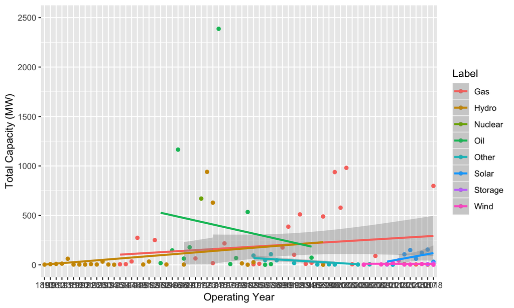

## Results - Map

This tab shows the location of all chosen power plants by leaflet map.

[interactive chart not shown]